# Reconstrucción del paper A: tarjetas experimentales y comparación

20 de octubre de 2026 · Comparación completa · Unidad: registro con ResponseId único, sin deduplicación entre personas.

## Resumen para decidir

La identificación por orden cambia la muestra y la distribución de las recomendaciones. Al retirar las respuestas ambiguas (C), quedan **2.587 registros docentes y 19.732 decisiones**, frente a 2.705 y 22.124 en A.

**47,62 → 41,72 %**Repetición en las tarjetas conservadas; cambio -5,90 pp. No es una tasa poblacional.

**54,62 → 54,95 pp**Coeficiente de tres o más suspensos.

**Covarianza singular en B, C y D**El modelo de seis pendientes converge en la frontera; se conserva y se documenta.

Lectura visual: las comparaciones se presentan en gráficos; las cifras exactas y los diagnósticos están en los desplegables y CSV.

**Recomendación:** usar C como referencia experimental conservadora para decidir la revisión, manteniendo por ahora el filtro vigente. B explicita el supuesto sobre campos compartidos; D comprueba sensibilidad a excluir docentes completos. Resolver por separado el filtro y la correspondencia de las tarjetas antes de adoptar una versión definitiva.

Se mantienen los efectos académicos dominantes y la escasa capacidad descriptiva de las covariables docentes. La corrección afecta especialmente a niveles descriptivos, distribución del harshness, grupos por terciles y diagnóstico del modelo mixto. Las conclusiones detalladas se apoyan en estimaciones nuevas e incertidumbre reconstruida.

## Qué compara cada escenario

### A

**Regla:** Todas las respuestas actuales salvo los dos campos favorables ya omitidos

**Interpretación:** Referencia reproducida; mantiene mezcla de ejemplos y tarea

### B

**Regla:** Sólo tarjetas de la secuencia FL válida, incluidas las coincidentes con ejemplos

**Interpretación:** Supone utilizable el valor compartido; no se demuestra que sea respuesta posterior

### C

**Regla:** B retirando sólo las observaciones coincidentes con los ejemplos del registro

**Interpretación:** Conserva el resto de respuestas válidas y las respuestas parciales

### D

**Regla:** B retirando todo registro cuyo conjunto asignado coincide con sus ejemplos

**Interpretación:** Sensibilidad con otra composición de docentes y tarjetas

A–D mantienen el cribado actual de registros basado en los cuatro campos favorables. A omite globalmente los campos `alumno_1_1` y `alumno_2_1`; B, C y D los admiten cuando están asignados y cumplen su regla de procedencia. Por eso el paso de A a B no es una simple resta de ejemplos. Las comprobaciones con ocho valores guardados y con otros filtros se presentan aparte. Una secuencia válida identifica asignación; un valor guardado identifica almacenamiento; ninguna de las dos cosas demuestra por sí sola una nueva respuesta tras el ejemplo.

En C se retiran observaciones. D elimina registros completos con cualquier coincidencia, incluidas sus respuestas no ambiguas. La condición de D depende de la combinación de bloque asignado y variante de Ejemplo: cambia participantes, mezcla de perfiles y referencias, además del tratamiento de los campos compartidos.

## Auditoría independiente de procedencia

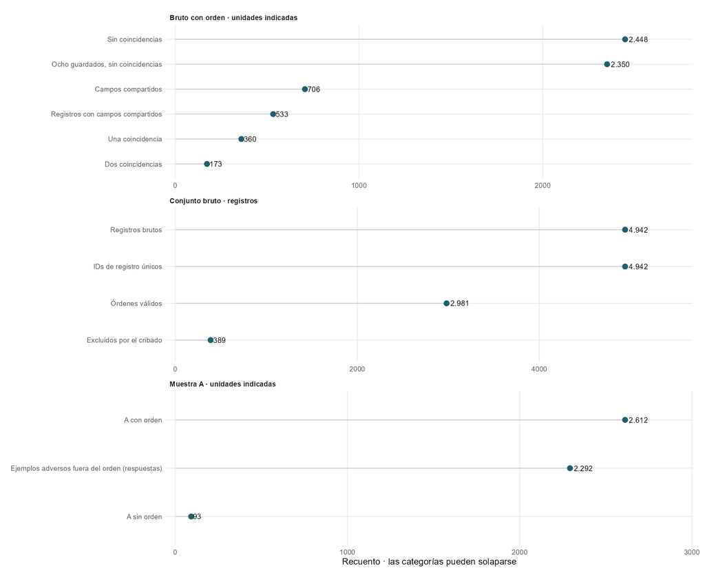

Recuentos por población de referencia. Las categorías se solapan: no deben sumarse; se distinguen registros, respuestas y campos.

**Ver cifras exactas y detalle técnico**

| Comprobación | Población | Recuento |
| --- | --- | --- |
| Registros brutos | Conjunto bruto | 4.942 |
| Identificadores de registro únicos | Conjunto bruto | 4.942 |
| Secuencias de ocho asignaciones válidas | Conjunto bruto | 2.981 |
| Registros sin coincidencias | Bruto con orden válido | 2.448 |
| Registros con una coincidencia | Bruto con orden válido | 360 |
| Registros con dos coincidencias | Bruto con orden válido | 173 |
| Registros sin coincidencias y con ocho valores guardados | Bruto con orden válido | 2.350 |
| Registros A con orden válido | Muestra A | 2.612 |
| Registros A sin orden válido | Muestra A | 93 |
| Respuestas de ejemplos adversos fuera de orden | Muestra A | 2.292 |
| Campos compartidos entre ejemplo y tarea | Bruto con orden válido | 706 |
| Registros con campos compartidos | Bruto con orden válido | 533 |
| Registros excluidos por el cribado vigente | Conjunto bruto | 389 |

Los valores 1–2 de `Ejemplo` se asocian con `alumno_1_1` y `alumno_3_8`; 3–4 con `alumno_2_1` y `alumno_2_8`. La comprobación usa la asociación con campos fuera del orden y los atributos codificados, no sólo perfiles extremos. Mapeos excepcionales: `alumno_3_5 → Grupo 5_1` y `alumno_6_1 → Grupo 6_1`.

Los campos compartidos tienen tiempos y clics positivos, pero también los tienen los ejemplos fuera de la secuencia. No existen en el export inspeccionado copias separadas por visita que permitan atribuir el valor a la presentación experimental. Los campos DO de la pregunta no equivalen a los FL de orden del bloque. `Calibracion` corresponde al control, no a superar atención.

Las 706 coincidencias y 533 registros se refieren al conjunto bruto con orden. Las 2.292 respuestas de ejemplo conservadas corresponden a la muestra actual. Estos recuentos tienen denominadores distintos y no deben sumarse.

La codificación vigente tiene 64 identificadores y 56 combinaciones distintas de atributos. Se mantiene para aislar la corrección de observaciones; sin el texto original completo de las tarjetas no se decide si las duplicaciones son deliberadas o errores. Se exportan las parejas y el soporte para verificarlas.

## Muestras y soporte

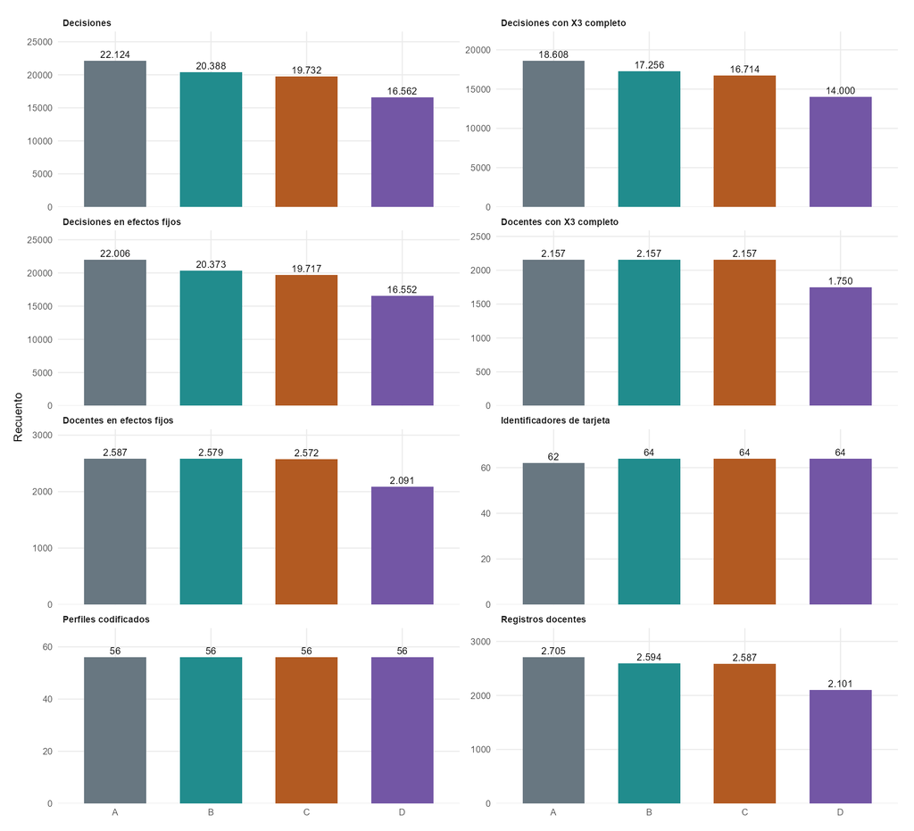

Docentes, decisiones, casos completos y soporte de tarjetas. Cada panel conserva su propia unidad y escala.

**Ver cifras exactas y detalle técnico**

| Escenario | Docentes | Decisiones | Docentes FE | Decisiones FE | Docentes con X3 completo | Decisiones de docentes con X3 completo | IDs tarjeta | Perfiles codificados |
| --- | --- | --- | --- | --- | --- | --- | --- | --- |
| A | 2.705 | 22.124 | 2.587 | 22.006 | 2.157 | 18.608 | 62 | 56 |
| B | 2.594 | 20.388 | 2.579 | 20.373 | 2.157 | 17.256 | 64 | 56 |
| C | 2.587 | 19.732 | 2.572 | 19.717 | 2.157 | 16.714 | 64 | 56 |
| D | 2.101 | 16.562 | 2.091 | 16.552 | 1.750 | 14.000 | 64 | 56 |

Los 2.612 registros actuales con orden incluyen casos sin ninguna respuesta guardada en las ocho tarjetas. Por eso B tiene 2.594 registros con resultado. C conserva 2.587: retirar sólo sus respuestas ambiguas deja a siete registros adicionales sin resultado. No se impone completar las ocho tarjetas.

## Qué observaciones cambia la reconstrucción

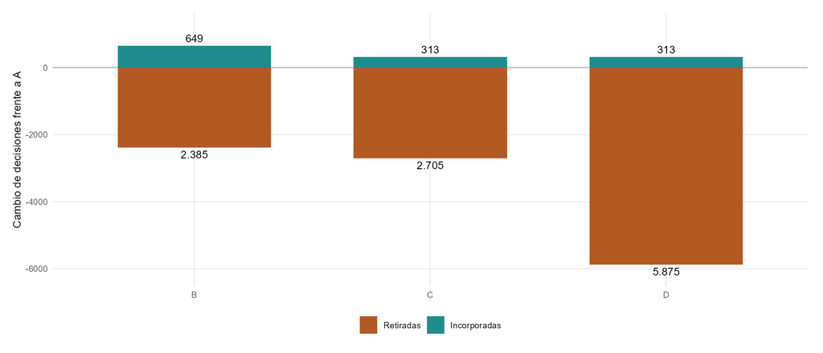

Decisiones retiradas e incorporadas respecto a A. Las barras inferiores representan retiradas; las superiores, incorporaciones.

**Ver cifras exactas y detalle técnico**

| Escenario | Respuestas retiradas de A | Respuestas incorporadas frente a A | Respuestas finales |
| --- | --- | --- | --- |
| B | 2.385 | 649 | 20.388 |
| C | 2.705 | 313 | 19.732 |
| D | 5.875 | 313 | 16.562 |

C no sólo resta ejemplos: recupera las respuestas a tarjetas favorables asignadas válidas que A omitía globalmente. Frente a A pierde 118 registros docentes y recupera 0. Entre los 2.587 docentes comunes, el 5,373 % cambia de tercil y el cambio absoluto medio de Hb es 2,9865 pp. Estas comparaciones de Hb usan las referencias propias de cada muestra nativa.

## Efectos within-teacher e interacciones

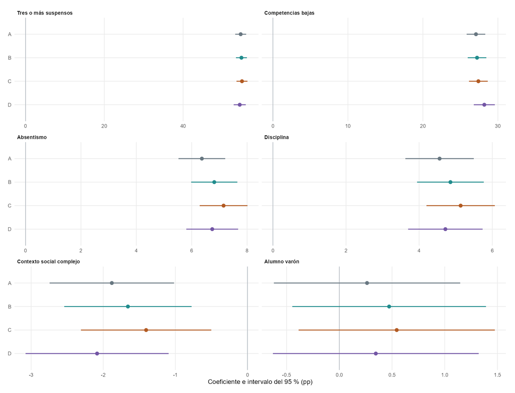

Seis coeficientes aditivos e IC del 95 % con errores agrupados por docente. Escalas horizontales propias de cada atributo.

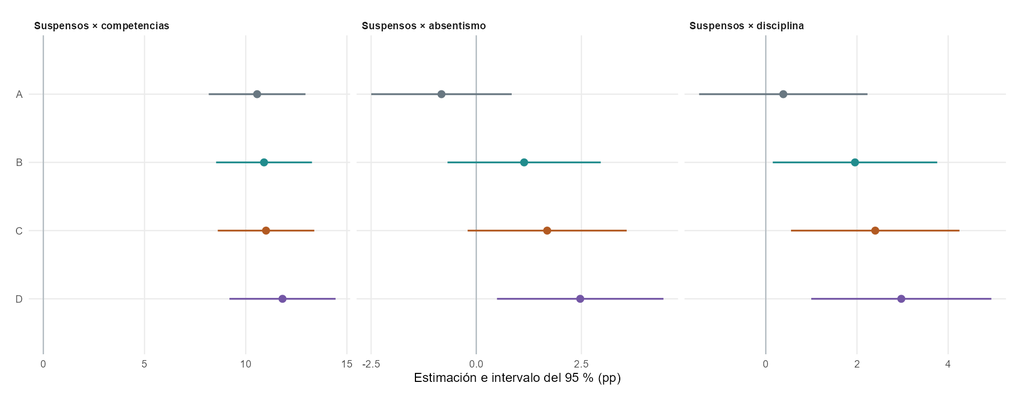

Tres interacciones e IC del 95 % con errores agrupados. Estos intervalos no están ajustados por multiplicidad; los p de Holm figuran en el detalle numérico.

**Ver cifras exactas y detalle técnico**

| Atributo | A | B | C | D | C − A (pp) |
| --- | --- | --- | --- | --- | --- |
| Tres o más suspensos | 54,62 [53,23; 56,01] | 54,81 [53,42; 56,21] | 54,95 [53,56; 56,35] | 54,38 [52,85; 55,91] | 0,33 |
| Competencias bajas | 27,07 [25,83; 28,31] | 27,22 [25,98; 28,46] | 27,40 [26,15; 28,65] | 28,19 [26,78; 29,59] | 0,32 |
| Absentismo | 6,37 [5,52; 7,21] | 6,81 [5,98; 7,65] | 7,15 [6,29; 8,01] | 6,74 [5,80; 7,68] | 0,78 |
| Disciplina | 4,56 [3,62; 5,50] | 4,86 [3,94; 5,77] | 5,14 [4,20; 6,07] | 4,72 [3,70; 5,74] | 0,58 |
| Contexto social complejo | -1,88 [-2,74; -1,02] | -1,66 [-2,54; -0,77] | -1,41 [-2,31; -0,50] | -2,09 [-3,08; -1,09] | 0,48 |
| Alumno varón | 0,26 [-0,62; 1,15] | 0,47 [-0,45; 1,39] | 0,54 [-0,39; 1,47] | 0,35 [-0,63; 1,32] | 0,28 |

El modelo aditivo incluye los seis atributos y efectos fijos docentes. El modelo de interacciones añade los tres términos especificados abajo, con ajuste de Holm sobre esas tres pruebas. El soporte y rango de matrices se verifican por escenario; no se añaden ni retiran términos para aproximar resultados.

**Ver cifras exactas y detalle técnico**

| Escenario | Interacción | Coeficiente (pp) | SE (pp) | IC 95 % (pp) | p Holm |
| --- | --- | --- | --- | --- | --- |
| A | Suspensos × competencias | 10,56 | 1,22 | [8,17; 12,95] | 2.26e-17 |
| B | Suspensos × competencias | 10,91 | 1,21 | [8,54; 13,27] | 9.87e-19 |
| C | Suspensos × competencias | 11,00 | 1,22 | [8,62; 13,39] | 8.22e-19 |
| D | Suspensos × competencias | 11,82 | 1,34 | [9,20; 14,44] | 5.94e-18 |
| A | Suspensos × absentismo | -0,83 | 0,85 | [-2,50; 0,84] | 0.663 |
| B | Suspensos × absentismo | 1,14 | 0,93 | [-0,68; 2,96] | 0.221 |
| C | Suspensos × absentismo | 1,69 | 0,96 | [-0,20; 3,58] | 0.0805 |
| D | Suspensos × absentismo | 2,47 | 1,01 | [0,49; 4,45] | 0.0144 |
| A | Suspensos × disciplina | 0,38 | 0,94 | [-1,46; 2,23] | 0.683 |
| B | Suspensos × disciplina | 1,96 | 0,92 | [0,15; 3,76] | 0.0669 |
| C | Suspensos × disciplina | 2,40 | 0,94 | [0,55; 4,25] | 0.0218 |
| D | Suspensos × disciplina | 2,97 | 1,01 | [1,00; 4,95] | 0.00641 |

La revisión también afecta a las interacciones conductuales. En C, suspensos × disciplina es 2,40 pp (p Holm 0,0218), frente a 0,38 pp en A (p Holm 0,683). D muestra interacciones positivas con absentismo y disciplina en una composición de docentes distinta. La comparación emparejada presenta la incertidumbre del cambio; comparar niveles de significación de dos modelos no prueba por sí solo una diferencia.

## Perfiles académicos y desacuerdo

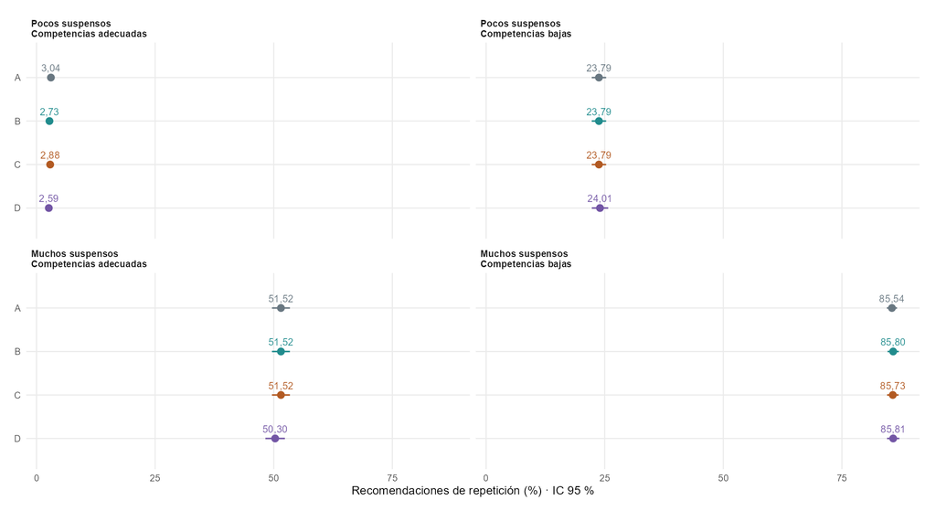

Repetición por categoría académica e IC del 95 % con errores agrupados por docente.

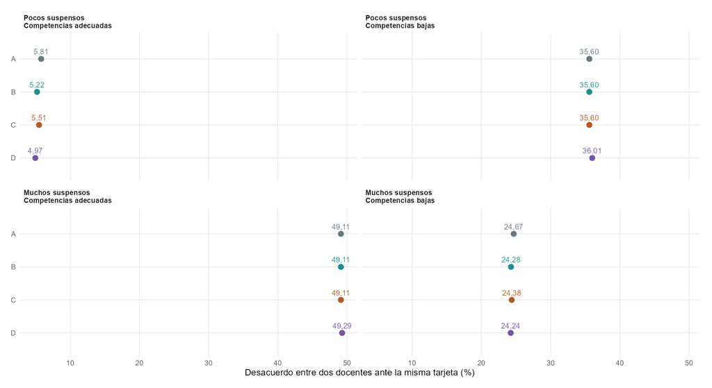

Desacuerdo entre dos docentes distintos ante el mismo identificador, ponderado por frecuencia; estimaciones puntuales.

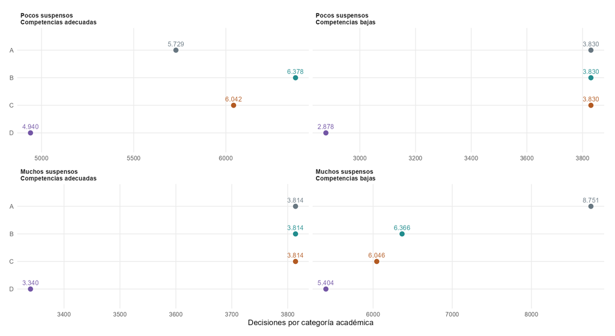

Número de decisiones en cada categoría académica y escenario.

**Ver cifras exactas y detalle técnico**

| Escenario | Perfil académico | Decisiones | Repetición (%) | SE tasa (pp) | Desacuerdo (%) |
| --- | --- | --- | --- | --- | --- |
| A | Few failures / adequate competence | 5.729 | 3,04 | 0,26 | 5,81 |
| A | Few failures / low competence | 3.830 | 23,79 | 0,77 | 35,60 |
| A | Many failures / adequate competence | 3.814 | 51,52 | 0,96 | 49,11 |
| A | Many failures / low competence | 8.751 | 85,54 | 0,55 | 24,67 |
| B | Few failures / adequate competence | 6.378 | 2,73 | 0,23 | 5,22 |
| B | Few failures / low competence | 3.830 | 23,79 | 0,77 | 35,60 |
| B | Many failures / adequate competence | 3.814 | 51,52 | 0,96 | 49,11 |
| B | Many failures / low competence | 6.366 | 85,80 | 0,60 | 24,28 |
| C | Few failures / adequate competence | 6.042 | 2,88 | 0,24 | 5,51 |
| C | Few failures / low competence | 3.830 | 23,79 | 0,77 | 35,60 |
| C | Many failures / adequate competence | 3.814 | 51,52 | 0,96 | 49,11 |
| C | Many failures / low competence | 6.046 | 85,73 | 0,62 | 24,38 |
| D | Few failures / adequate competence | 4.940 | 2,59 | 0,26 | 4,97 |
| D | Few failures / low competence | 2.878 | 24,01 | 0,88 | 36,01 |
| D | Many failures / adequate competence | 3.340 | 50,30 | 1,05 | 49,29 |
| D | Many failures / low competence | 5.404 | 85,81 | 0,66 | 24,24 |

Las tasas son medias observadas de cada categoría, con SE agrupados por docente. El desacuerdo compara dos docentes distintos ante el mismo identificador y pondera por frecuencia. No estandariza los otros atributos ni mide por sí solo persistencia, arbitrariedad o calidad de la decisión.

## Qué cambia en la dispersión de harshness

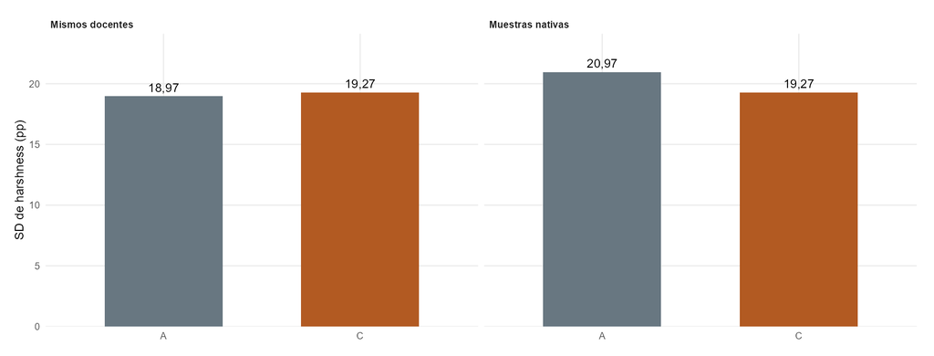

La SD de Hb se compara primero en las muestras nativas y después en exactamente los mismos docentes. Barras desde cero.

La SD de Hb en las muestras nativas pasa de 20,97 pp (A) a 19,27 pp (C). En cambio, al conservar los mismos docentes y reconstruir las referencias, pasa de 18,97 a 19,27 pp. La reducción total combina cambios de muestra y de respuestas; no debe atribuirse íntegramente a retirar ejemplos.

## Comparaciones en los mismos docentes

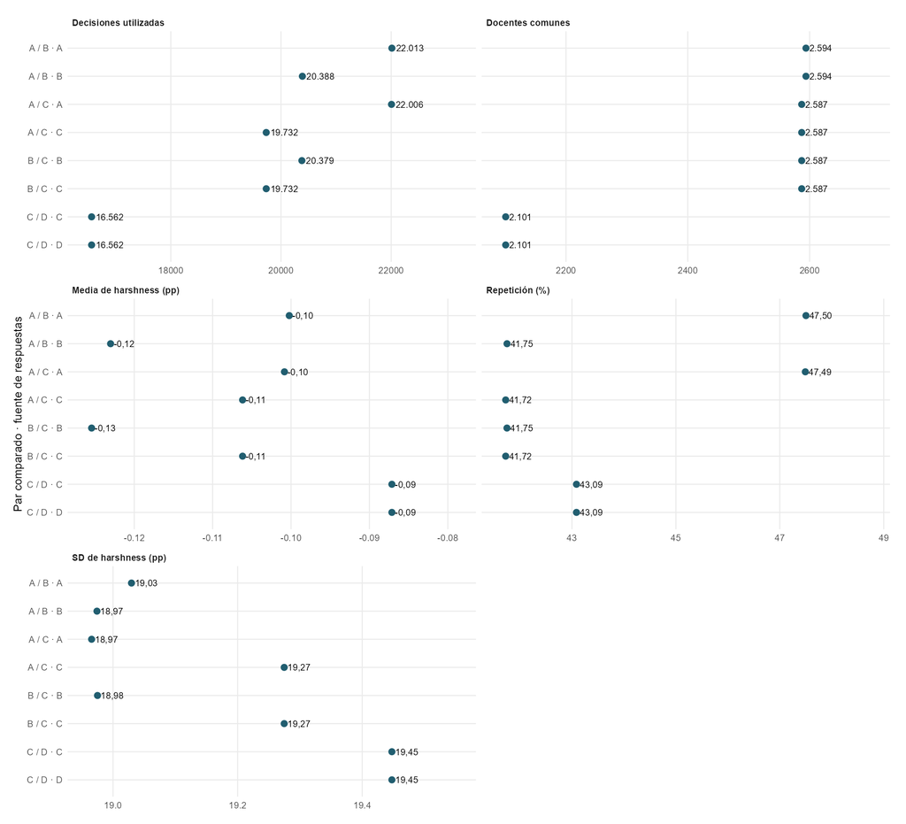

Cada par utiliza los mismos registros docentes en sus dos filas; las referencias se reconstruyen por separado. En C / D coinciden los resultados de ambas fuentes.

**Ver cifras exactas y detalle técnico**

| Comparación | Respuestas de | Docentes comunes | Decisiones | Repetición (%) | Media Hb (pp) | SD Hb (pp) |
| --- | --- | --- | --- | --- | --- | --- |
| A frente a B | A | 2.594 | 22.013 | 47,50 | -0,10 | 19,03 |
| A frente a B | B | 2.594 | 20.388 | 41,75 | -0,12 | 18,97 |
| A frente a C | A | 2.587 | 22.006 | 47,49 | -0,10 | 18,97 |
| A frente a C | C | 2.587 | 19.732 | 41,72 | -0,11 | 19,27 |
| B frente a C | B | 2.587 | 20.379 | 41,75 | -0,13 | 18,98 |
| B frente a C | C | 2.587 | 19.732 | 41,72 | -0,11 | 19,27 |
| C frente a D | C | 2.101 | 16.562 | 43,09 | -0,09 | 19,45 |
| C frente a D | D | 2.101 | 16.562 | 43,09 | -0,09 | 19,45 |

Cada par se restringe a sus registros docentes comunes y reconstruye sus referencias y Hb en esa población. Esto separa la composición de docentes del cambio de respuestas utilizadas, sin convertir las diferencias en efectos causales.

En la intersección C–D, ambas fuentes contienen exactamente 2.101 registros y 16.562 respuestas: coinciden la tasa de repetición (43,09 %), la media de Hb (-0,09 pp) y su desviación estándar (19,45 pp) al recalcular las referencias en ese mismo conjunto. D no retira respuestas adicionales dentro de estos docentes. Las diferencias entre las muestras nativas C y D reflejan la exclusión de otros 486 registros, la mezcla resultante de tarjetas y la reconstrucción de referencias. Es una sensibilidad de composición, no una segunda corrección de las respuestas de los docentes comunes.

## Harshness, definiciones alternativas y terciles

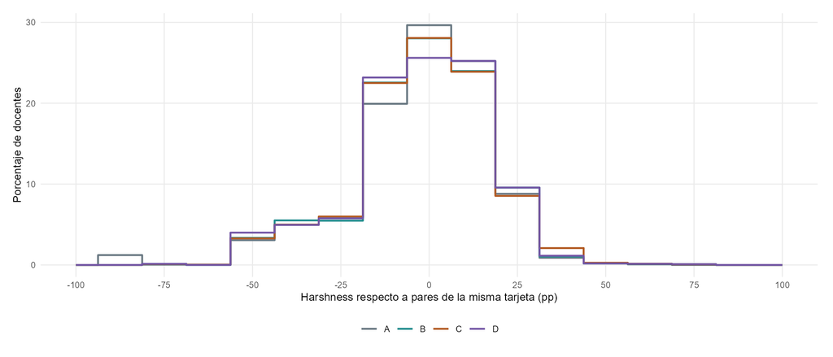

Distribuciones de Hb con clases de 12,5 pp centradas en cero; porcentaje de docentes por clase.

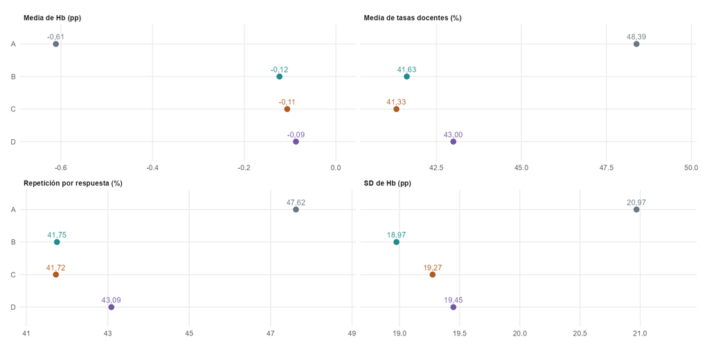

Niveles de repetición, media y dispersión de Hb. Las tasas por respuesta y por docente tienen ponderaciones distintas.

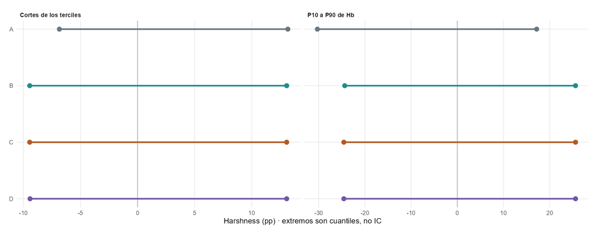

Cuantiles de la distribución y cortes de los terciles: los segmentos no son intervalos de confianza.

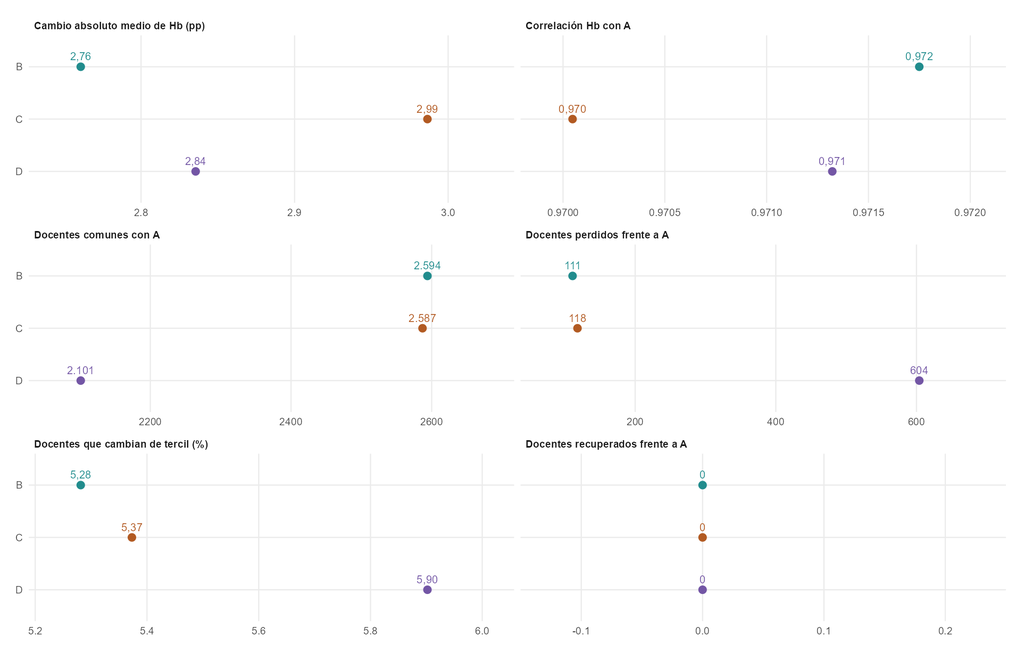

Cambios de Hb y de tercil respecto a A entre registros compartidos, con las referencias de cada muestra nativa.

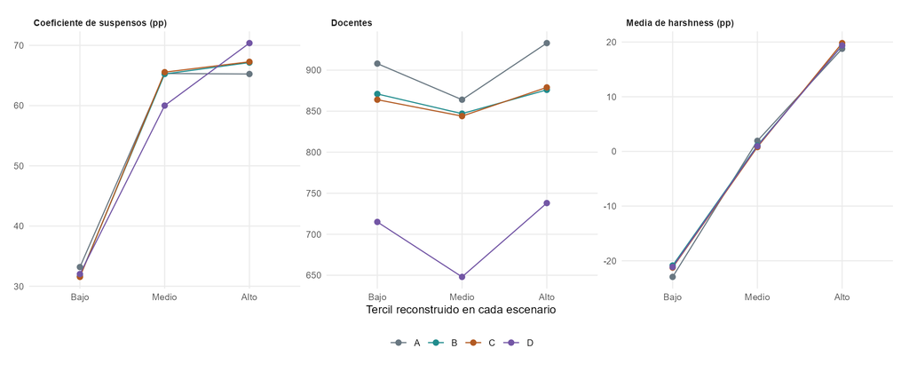

Tamaño, harshness medio y coeficiente de suspensos por tercil. Los grupos se construyen con las propias respuestas: comparación descriptiva.

**Ver cifras exactas y detalle técnico**

| Escenario | Repetición ponderada por respuesta (%) | Media de tasas docentes (%) | Media Hb (pp) | SD Hb (pp) | P10 Hb (pp) | P90 Hb (pp) | Corte tercil 1 (pp) | Corte tercil 2 (pp) |
| --- | --- | --- | --- | --- | --- | --- | --- | --- |
| A | 47,62 | 48,39 | -0,61 | 20,97 | -30,28 | 17,18 | -6,85 | 13,15 |
| B | 41,75 | 41,63 | -0,12 | 18,97 | -24,37 | 25,59 | -9,45 | 13,05 |
| C | 41,72 | 41,33 | -0,11 | 19,27 | -24,56 | 25,59 | -9,45 | 13,05 |
| D | 43,09 | 43,00 | -0,09 | 19,45 | -24,56 | 25,59 | -9,42 | 13,05 |

**Ver cifras exactas y detalle técnico**

| Escenario | Docentes comunes | Pierde frente A | Recupera frente A | Correlación Hb | Cambio absoluto medio (pp) | Cambia tercil (%) |
| --- | --- | --- | --- | --- | --- | --- |
| B | 2594 | 111 | 0 | 0,972 | 2,76 | 5,28 |
| C | 2587 | 118 | 0 | 0,970 | 2,99 | 5,37 |
| D | 2101 | 604 | 0 | 0,971 | 2,84 | 5,90 |

Las referencias leave-one-out, el harshness, sus terciles y Hc/Hd se recalculan para cada escenario. La media de Hb ponderada por respuestas es cero por construcción; su media no ponderada por docente no tiene que serlo. Las regresiones por tercil siguen siendo descriptivas porque el grupo se construye con las mismas decisiones.

**Ver cifras exactas y detalle técnico**

| Escenario | Tercil | Docentes | Media Hb (pp) | Suspensos (pp) |
| --- | --- | --- | --- | --- |
| A | Lower | 908 | -22,95 | 33,19 |
| A | Middle | 864 | 1,94 | 65,33 |
| A | Upper | 933 | 18,77 | 65,25 |
| B | Lower | 871 | -20,87 | 31,66 |
| B | Middle | 847 | 1,08 | 65,25 |
| B | Upper | 876 | 19,34 | 67,15 |
| C | Lower | 864 | -21,24 | 31,56 |
| C | Middle | 844 | 0,79 | 65,55 |
| C | Upper | 879 | 19,81 | 67,28 |
| D | Lower | 715 | -21,13 | 32,04 |
| D | Middle | 648 | 0,97 | 60,00 |
| D | Upper | 738 | 19,37 | 70,38 |

Las tablas completas de los tres terciles, sus seis pendientes y las cuatro definiciones alternativas están disponibles en los CSV por escenario.

## Características y creencias docentes

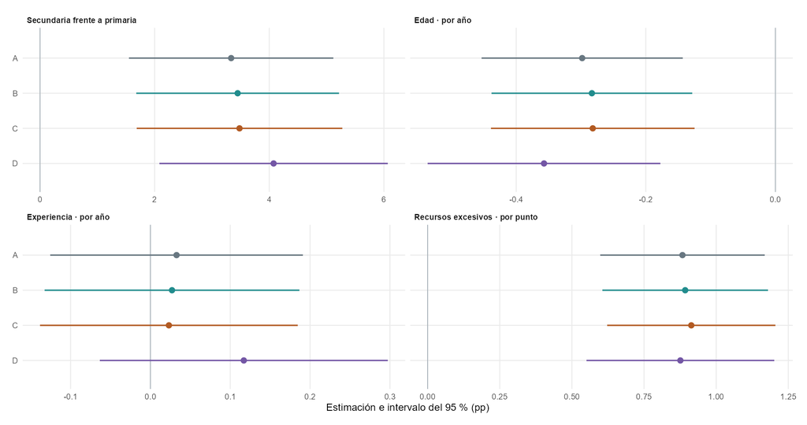

Coeficientes de X3 e IC del 95 % HC3. Edad y experiencia se expresan por año; recursos, por punto de la escala.

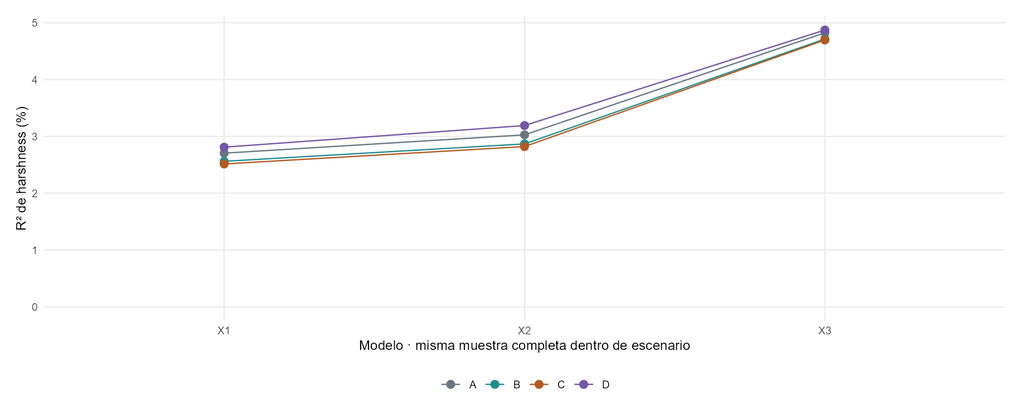

R² de los modelos X1–X3, con la misma muestra completa dentro de cada escenario; el eje parte de cero.

**Ver cifras exactas y detalle técnico**

| Escenario | Variable | Coeficiente (pp) | HC3 SE (pp) | Docentes con X3 completo | R² (%) |
| --- | --- | --- | --- | --- | --- |
| A | Secundaria | 3,33 | 0,91 | 2.157 | 4,82 |
| A | Edad | -0,30 | 0,08 | 2.157 | 4,82 |
| A | Experiencia | 0,03 | 0,08 | 2.157 | 4,82 |
| A | Recursos excesivos | 0,88 | 0,15 | 2.157 | 4,82 |
| B | Secundaria | 3,45 | 0,90 | 2.157 | 4,71 |
| B | Edad | -0,28 | 0,08 | 2.157 | 4,71 |
| B | Experiencia | 0,03 | 0,08 | 2.157 | 4,71 |
| B | Recursos excesivos | 0,89 | 0,15 | 2.157 | 4,71 |
| C | Secundaria | 3,48 | 0,91 | 2.157 | 4,70 |
| C | Edad | -0,28 | 0,08 | 2.157 | 4,70 |
| C | Experiencia | 0,02 | 0,08 | 2.157 | 4,70 |
| C | Recursos excesivos | 0,91 | 0,15 | 2.157 | 4,70 |
| D | Secundaria | 4,08 | 1,02 | 1.750 | 4,87 |
| D | Edad | -0,36 | 0,09 | 1.750 | 4,87 |
| D | Experiencia | 0,12 | 0,09 | 1.750 | 4,87 |
| D | Recursos excesivos | 0,88 | 0,17 | 1.750 | 4,87 |

Los modelos X1–X3 usan la misma muestra completa dentro de cada escenario. Se mantiene HC3. El bootstrap adicional de 999 sorteos vuelve a construir las referencias y Hb. Las creencias son posteriores a las decisiones y sus asociaciones no identifican mecanismos causales.

## Descomposición y estado de su incertidumbre

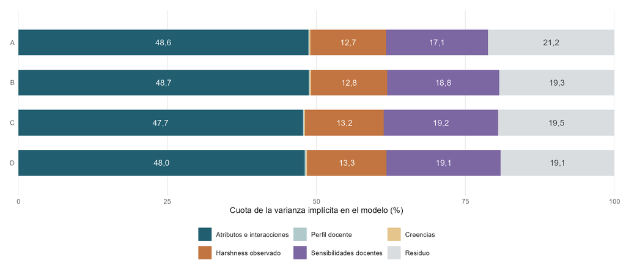

Cuotas puntuales del mismo modelo y reparto. Cada barra suma el 100 % de la varianza implícita en el modelo.

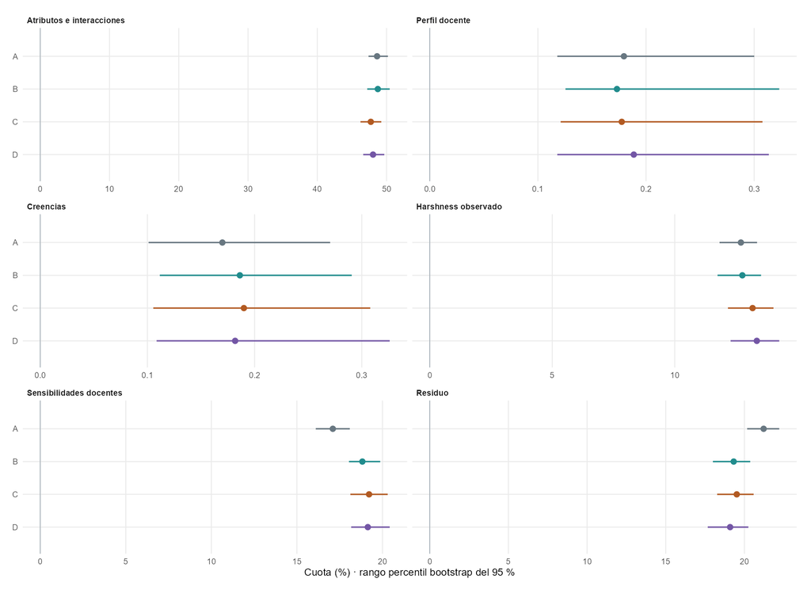

Puntos y rangos percentiles del 95 % de las 199 remuestras docentes por escenario. Describen dispersión; no acreditan cobertura nominal en la frontera.

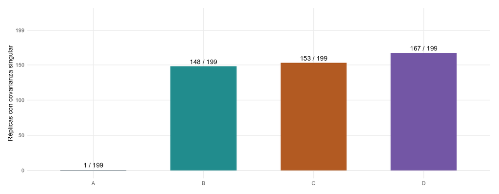

Número de remuestras con covarianza singular, de 199 aceptadas por escenario. El punto es singular en B, C y D.

**Ver cifras exactas y detalle técnico**

| Componente | A | B | C | D | C − A (pp) |
| --- | --- | --- | --- | --- | --- |
| Atributos e interacciones | 48,63 (SE 0,74) | 48,74 (SE 0,80) | 47,73 (SE 0,80) | 48,04 (SE 0,78) | -0,90 |
| Perfil docente | 0,18 (SE 0,05) | 0,17 (SE 0,05) | 0,18 (SE 0,05) | 0,19 (SE 0,05) | -0,00 |
| Creencias | 0,17 (SE 0,04) | 0,19 (SE 0,05) | 0,19 (SE 0,05) | 0,18 (SE 0,06) | 0,02 |
| Harshness observado | 12,70 (SE 0,43) | 12,76 (SE 0,46) | 13,18 (SE 0,48) | 13,35 (SE 0,49) | 0,48 |
| Sensibilidades docentes | 17,10 (SE 0,53) | 18,83 (SE 0,51) | 19,22 (SE 0,58) | 19,14 (SE 0,59) | 2,12 |
| Residuo | 21,22 (SE 0,56) | 19,32 (SE 0,58) | 19,51 (SE 0,61) | 19,09 (SE 0,63) | -1,71 |

**Ver cifras exactas y detalle técnico**

| Escenario | Rango fijo | Parámetros covarianza | Singular | Gradiente combinado | Hessiana mín. | Fuera [0,1] (%) | Bootstrap aceptadas | Réplicas singulares |
| --- | --- | --- | --- | --- | --- | --- | --- | --- |
| A | 34 | 21 | False | 0,001000 | 165,933 | 25,54 | 199/199 | 1 |
| B | 34 | 21 | True | 0,000100 | 75,131 | 27,67 | 199/199 | 148 |
| C | 34 | 21 | True | 0,001200 | 60,271 | 27,00 | 199/199 | 153 |
| D | 34 | 21 | True | 0,001700 | 60,037 | 26,85 | 199/199 | 167 |

Se mantienen seis atributos y sus 15 interacciones, X1, las creencias añadidas a X1 (X3 menos X1), Hb observado y seis pendientes correlacionadas centradas en las decisiones de docentes con X3 completo. No se introduce intercepto aleatorio ni bloque de ramas experimentales. Se usa REML y reparto Shapley por proyección del mismo predictor fijo. También se exportan los componentes sin normalizar y el denominador.

**Singularidad:** la matriz de covarianzas corregida está en la frontera. Esto no equivale a que el optimizador no haya encontrado una solución, pero impide describirla como seis dimensiones aleatorias no degeneradas. Se conserva la especificación. El bootstrap de 199 sorteos por escenario describe la dispersión del estimador, reconstruyendo referencias y Hb y refitando el modelo; los rangos percentiles no acreditan cobertura nominal en la frontera. Se registran fallos, avisos y ajustes singulares, sin sustituir semillas para conseguir éxitos.

Las copias de un docente remuestreado reciben identificadores de cluster distintos. La referencia resta una copia de su respuesta. Se comprueba algebraicamente esta construcción frente a una expansión explícita. Se aplica a todas las configuraciones el criterio original del script 49: código de optimizador cero y cuotas finitas, conservando los ajustes singulares. Las filas v2 tienen diagnósticos adicionales de gradiente/Hessiana y, cuando hacía falta, un intento BOBYQA; esos diagnósticos quedan registrados. Las filas v3 mantienen inicio automático y omiten el cálculo posterior de derivadas en cada remuestra, igual que el bootstrap original. La comprobación de nueve casos preespecificados verifica que ese indicador deja iguales el objetivo y el reparto. Los diagnósticos completos de todos los puntos se conservan. No se afirma haber verificado la Hessiana en todas las réplicas.

B v1 se descarta por obtener menor log-verosimilitud REML que las soluciones alternativas auditadas; sus 199 réplicas se vuelven a estimar. En C y D se conservan las filas v1 tras la auditoría preespecificada de inicialización, y cada fila restante identifica su configuración. Los controles por semillas no garantizan el óptimo global de todas las remuestras. La auditoría de inicializaciones y tolerancias se documenta en optimizer_control_audit.csv y en los estados por escenario.

Harshness se construye con las propias respuestas. El reparto describe estructura dentro de muestra y no es exactitud predictiva, atribución causal, estabilidad temporal ni un criterio para clasificar profesores. Los porcentajes fuera de [0,1] son predicciones condicionales del modelo lineal y no se recortan para descomponer.

## Cuánto cambia: comparación emparejada

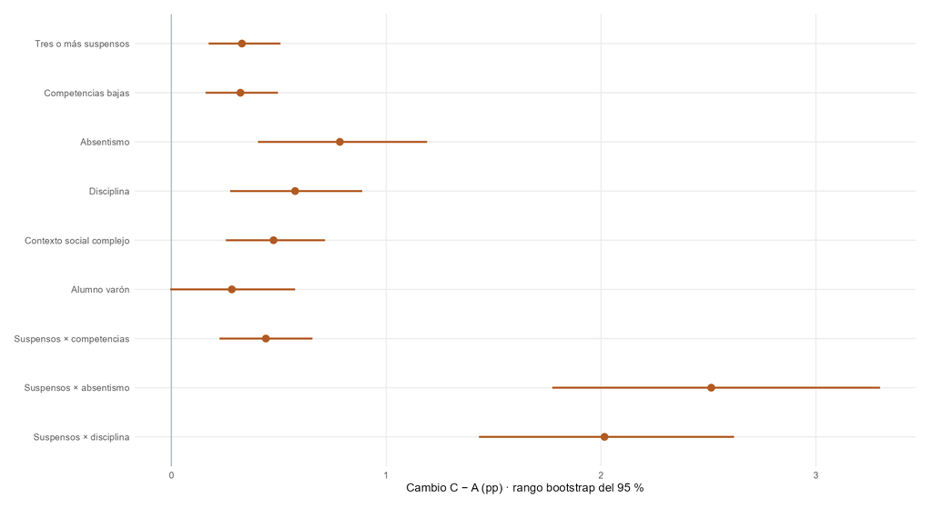

Cambio C − A y rango bootstrap del 95 %, con 999 sorteos emparejados. La línea vertical señala ausencia de cambio.

**Ver cifras exactas y detalle técnico**

| Métrica | Cambio (pp) | Rango bootstrap 95 % (pp) | Sorteos válidos |
| --- | --- | --- | --- |
| Absentismo | 0,78 | [0,40; 1,19] | 999 |
| Contexto social complejo | 0,48 | [0,25; 0,72] | 999 |
| Competencias bajas | 0,32 | [0,16; 0,50] | 999 |
| Disciplina | 0,58 | [0,27; 0,89] | 999 |
| Tres o más suspensos | 0,33 | [0,17; 0,51] | 999 |
| Alumno varón | 0,28 | [-0,01; 0,58] | 999 |
| Suspensos × absentismo | 2,51 | [1,77; 3,30] | 999 |
| Suspensos × competencias | 0,44 | [0,22; 0,66] | 999 |
| Suspensos × disciplina | 2,02 | [1,43; 2,62] | 999 |

Se usan los mismos sorteos de registros docentes origen para A–D, con 999 repeticiones y semilla 20261020. Las referencias se vuelven a calcular dentro de cada escenario. Los tamaños realizados pueden variar en escenarios anidados. Se comparan cambios de estimación, no “significativo frente a no significativo”. El CSV incluye B−A, C−A, D−A, C−B y D−C. Las diferencias de cuotas del modelo mixto se presentan descriptivamente; sus SE marginales no se convierten en SE de diferencias.

## Sensibilidades de completitud y filtro

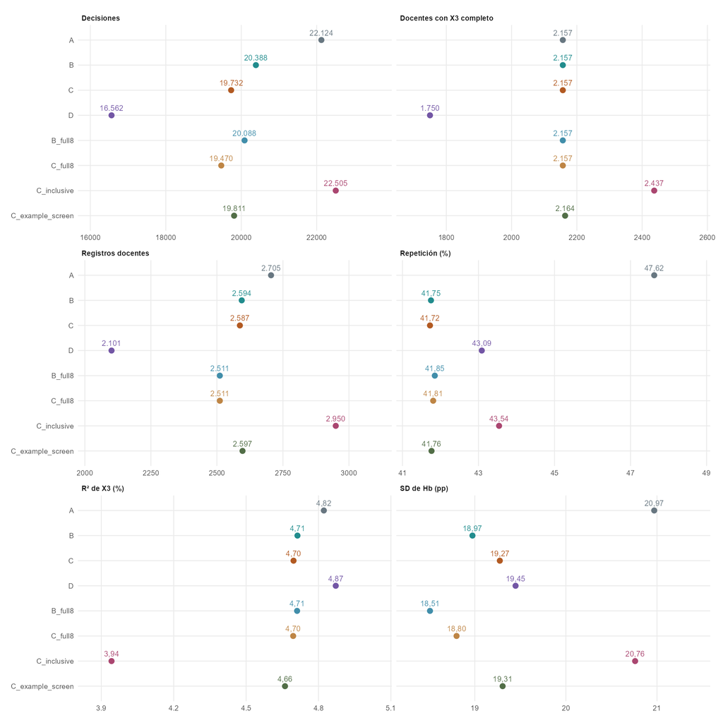

Ocho escenarios: muestras, repetición, dispersión de Hb y R². B_full8/C_full8: ocho valores guardados; C_inclusive: sin filtro de decisión; C_example_screen: filtro específico.

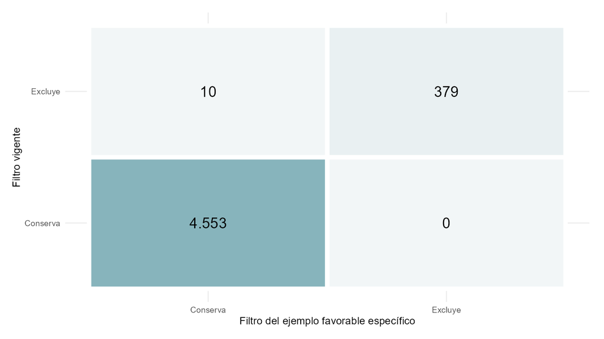

Intersección de los dos cribados en los 4.942 registros brutos. Se incluye explícitamente la celda vacía de cero registros.

**Ver cifras exactas y detalle técnico**

| Escenario | Docentes | Decisiones | Docentes con X3 completo | Repetición (%) | SD Hb (pp) | R² X3 (%) |
| --- | --- | --- | --- | --- | --- | --- |
| A · Actual | 2.705 | 22.124 | 2.157 | 47,62 | 20,97 | 4,82 |
| B · Ordenadas, incluidas coincidencias | 2.594 | 20.388 | 2.157 | 41,75 | 18,97 | 4,71 |
| C · Sin respuestas ambiguas | 2.587 | 19.732 | 2.157 | 41,72 | 19,27 | 4,70 |
| D · Docentes sin coincidencias | 2.101 | 16.562 | 1.750 | 43,09 | 19,45 | 4,87 |
| B · Ocho valores guardados | 2.511 | 20.088 | 2.157 | 41,85 | 18,51 | 4,71 |
| C · Ocho guardados, retirando ambiguos | 2.511 | 19.470 | 2.157 | 41,81 | 18,80 | 4,70 |
| C · Sin filtro por decisiones | 2.950 | 22.505 | 2.437 | 43,54 | 20,76 | 3,94 |
| C · Filtro del ejemplo favorable específico | 2.597 | 19.811 | 2.164 | 41,76 | 19,31 | 4,66 |

**Ver cifras exactas y detalle técnico**

| legacy | example_only | n |
| --- | --- | --- |
| False | False | 4553 |
| True | False | 10 |
| True | True | 379 |

**Ocho guardados:** B_full8 y C_full8 condicionan a disponer de ocho valores guardados en las posiciones asignadas; no se interpretan como prueba de recontestación ni se fuerzan ocho decisiones en C. Son sensibilidades de selección y no sustituyen las muestras parciales.

**Filtro:** en el conjunto bruto, el filtro vigente excluye 389 registros y el favorable específico de Ejemplo excluye 379. C_example_screen sustituye el cribado vigente de cuatro campos por el favorable específico de Ejemplo. Frente a C recupera diez registros con resultado, 79 respuestas y siete docentes con X3 completo. La procedencia del campo usado para cribar sigue siendo ambigua si se reutilizó. C_inclusive elimina todo filtro basado en esas decisiones. Ambas sensibilidades reconstruyen los resultados y mantienen separado el problema del cribado.

Las sensibilidades suplementarias tienen estimaciones puntuales y diagnósticos del mismo modelo mixto; el remuestreo intensivo de descomposición se concentra en A–D. Todas tienen HC3 y bootstrap de caracterización nuevos. Sus pendientes, soporte, tasas y grupos se exportan por separado. No se usan SE antiguos para estimaciones nuevas.

## Descomposición puntual de las sensibilidades

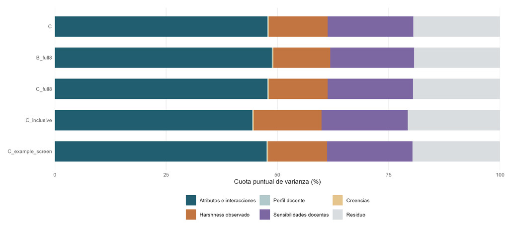

Cuotas puntuales en C y las cuatro sensibilidades; no se añaden intervalos bootstrap que no se hayan estimado.

**Ver cifras exactas y detalle técnico**

| Escenario | Atributos (%) | Perfil (%) | Creencias (%) | Hb (%) | Pendientes (%) | Residuo (%) |
| --- | --- | --- | --- | --- | --- | --- |
| C | 47,73 | 0,18 | 0,19 | 13,18 | 19,22 | 19,51 |
| B_full8 | 48,73 | 0,17 | 0,19 | 12,76 | 18,82 | 19,33 |
| C_full8 | 47,74 | 0,18 | 0,19 | 13,16 | 19,22 | 19,52 |
| C_inclusive | 44,36 | 0,10 | 0,24 | 15,20 | 19,38 | 20,72 |
| C_example_screen | 47,53 | 0,18 | 0,19 | 13,27 | 19,14 | 19,69 |

Son puntos del mismo modelo, con referencias y casos completos propios; las sensibilidades suplementarias no tienen aquí rangos bootstrap de descomposición. Al retirar el filtro basado en decisiones (C_inclusive), atributos e interacciones representan 44,36 % y Hb 15,20 %. El filtro afecta a la población y al reparto; su decisión debe mantenerse separada de corregir la identificación de tarjetas.

## Consistencia entre mitades de respuestas

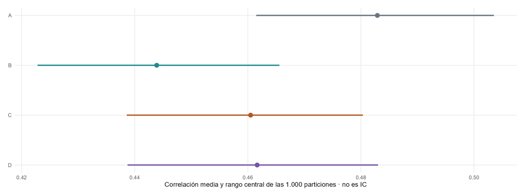

Media y rango central de las 1.000 particiones. El segmento mide sensibilidad a particiones; no es un IC muestral ni estabilidad temporal.

**Ver cifras exactas y detalle técnico**

| Escenario | Docentes elegibles | Mínimo de respuestas | Particiones | Correlación media | Rango central de particiones |
| --- | --- | --- | --- | --- | --- |
| A | 2.369 | 8 | 1.000 | 0,4829 | [0,4615; 0,5035] |
| B | 2.511 | 8 | 1.000 | 0,4439 | [0,4228; 0,4656] |
| C | 2.044 | 8 | 1.000 | 0,4605 | [0,4386; 0,4804] |
| D | 2.044 | 8 | 1.000 | 0,4617 | [0,4387; 0,4830] |

Se usan 1.000 particiones de respuestas y referencias externas disjuntas, con las semillas documentadas por escenario. La correlación compara mitades del mismo encuentro. El rango central describe sensibilidad a particiones; no es un intervalo de confianza muestral ni evidencia de estabilidad temporal. La composición de docentes elegibles y las referencias cambian entre escenarios.

## Participación, progresión y apéndices

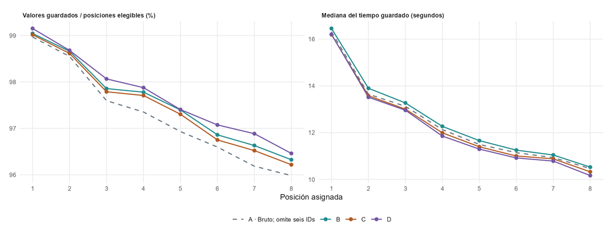

Progresión y tiempos guardados: A usa el denominador bruto y omite seis IDs; B/C/D usan sus elegibles. Los tiempos no equivalen a lectura activa.

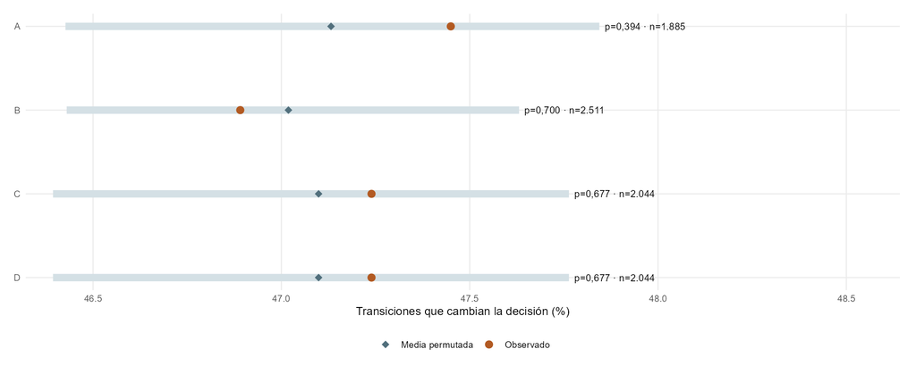

Cambio observado de decisión frente a la media y rango central de la distribución de permutación. Se indican el p bilateral y las secuencias completas utilizadas.

**Ver cifras exactas y detalle técnico**

| Escenario | Secuencias con 8 valores usados | Cambios observados (%) | Referencia de permutación (%) | p bilateral |
| --- | --- | --- | --- | --- |
| A | 1.885 | 47,45 | 47,13 | 0,394 |
| B | 2.511 | 46,89 | 47,02 | 0,700 |
| C | 2.044 | 47,24 | 47,10 | 0,677 |
| D | 2.044 | 47,24 | 47,10 | 0,677 |

Se reconstruye el denominador de participación desde experiencia: 4.037 registros, apartando 905 entradas mínimas. Las marcas Grupo1–Grupo8 indican cierre del bloque; B2_complet y finalizar encuesta son indicadores distintos. Se mantienen casos parciales. Se exportan el flujo de elegibilidad y resultado por escenario, composición poblacional, disponibilidad de creencias y covariables, tiempos y progresión.

En C se eliminan coincidencias específicas del registro, en vez de retirar seis identificadores globalmente. El cambio de denominador temporal se presenta aparte de los resultados analíticos. Los tiempos son envíos de página, no lectura activa ni prueba de fatiga. Las transiciones adyacentes sólo cuentan posiciones consecutivas; la permutación se aplica a secuencias completas con ocho resultados utilizados. El nuevo cálculo Monte Carlo para A da p = 0,394, frente a 0,397 en el manuscrito; ambos mantienen la misma lectura de falta de evidencia de compensación. No se afirma identidad de sorteos con la simulación archivada.

La comparación poblacional conserva la fuente 2023/24 y los márgenes del informe vigente. El código postal de los registros retenidos usa la limpieza actual; los recuperados al retirar el filtro sólo disponen del código declarado sin esa corrección. Las provincias de esa sensibilidad requieren esa cautela adicional.

## Qué conservaría y qué revisaría del manuscrito

### Suspensos y competencias dominan

**Balance:** Se mantiene

**Evidencia o límite:** C: 54,95 y 27,40 pp

### Absentismo y disciplina añaden información

**Balance:** Se mantiene con cambios de magnitud

**Evidencia o límite:** C: 7,15 y 5,14 pp

### Interacciones de suspensos con conducta

**Balance:** Se refuerzan en C; D cambia la composición

**Evidencia o límite:** C: suspensos × disciplina 2,40 pp, p Holm 0,0218; comparar cambios con su incertidumbre emparejada

### Contexto complejo modera la repetición

**Balance:** Se mantiene en C; menor magnitud

**Evidencia o límite:** A -1,88; C -1,41 pp

### Género sin efecto medio detectable

**Balance:** Se mantiene con incertidumbre

**Evidencia o límite:** No equivale a demostrar ausencia de sesgos

### Mayor desacuerdo en suspensos con competencias adecuadas

**Balance:** Se mantiene

**Evidencia o límite:** C: 49,11 % de pares

### X1–X3 explican menos del 5 % de Hb observado

**Balance:** Se mantiene en A–D

**Evidencia o límite:** C: R² 4,70 %

### Distribución y terciles de harshness

**Balance:** Necesitan actualización

**Evidencia o límite:** Cambian referencias, población y composición de tarjetas

### Cuotas exactas y matriz no singular del modelo actual

**Balance:** Requieren revisión sustantiva

**Evidencia o límite:** B/C/D convergen con covarianza singular; los porcentajes son descriptivos

### Flujo, recuentos y apéndices

**Balance:** Necesitan actualización

**Evidencia o límite:** Separar ejemplos, asignación, valores guardados y cierre del bloque

Esta comparación no ha editado el paper A, el B ni sus PDF. C es la referencia recomendada para evaluar la retirada de respuestas ambiguas con las exclusiones vigentes. La sensibilidad del filtro debe decidirse con su justificación sustantiva y la evidencia de procedencia; D no se elige por su parecido con A ni por conservar resultados significativos.

## Verificación, reproducibilidad y archivos

103 comprobaciones numéricas y de procedencia superadas. A se contrasta por claves con los resultados congelados. Se verifican referencias, expansión de clones, rangos, convergencia y sumas. R y lme4 se fijan también en los procesos paralelos. Se guardan semillas, versiones, huellas y estados de réplica.

- A · Actual: resumen · atributos · caracterización · descomposición, SE y rangos percentiles
- B · Ordenadas, incluidas coincidencias: resumen · atributos · caracterización · descomposición, SE y rangos percentiles
- C · Sin respuestas ambiguas: resumen · atributos · caracterización · descomposición, SE y rangos percentiles
- D · Docentes sin coincidencias: resumen · atributos · caracterización · descomposición, SE y rangos percentiles
- B · Ocho valores guardados: resumen · atributos · caracterización · descomposición puntual
- C · Ocho guardados, retirando ambiguos: resumen · atributos · caracterización · descomposición puntual
- C · Sin filtro por decisiones: resumen · atributos · caracterización · descomposición puntual
- C · Filtro del ejemplo favorable específico: resumen · atributos · caracterización · descomposición puntual

Verificaciones · Diferencias emparejadas · Participación · Cribado · Mapeo de tarjetas · Auditoría de inicialización · Integridad de archivos protegidos

Código aislado: `2. Code/paper_A_reconstruction/`. Datos por registro, secuencias y modelos: subcarpeta `local/`, excluida de Git. Sólo se versionan código, copias documentales y resultados agregados.